# Assignment 7

## Answer 10.1b

```r
#Random forest

#RF model
rf<-randomForest(Crime~., data=crime_data)
summary(rf)
```

```
##                 Length Class  Mode
## call              3    -none- call
## type              1    -none- character
## predicted        47    -none- numeric
## mse             500    -none- numeric
## rsq             500    -none- numeric
## oob.times        47    -none- numeric
## importance       15    -none- numeric
## importanceSD      0    -none- NULL
## localImportance   0    -none- NULL
## proximity         0    -none- NULL
## ntree             1    -none- numeric
## mtry              1    -none- numeric
## forest           11    -none- list
## coefs             0    -none- NULL
## y                47    -none- numeric
## test              0    -none- NULL
## inbag             0    -none- NULL
## terms             3    terms  call
```

```r
print(rf)
```

```
##
## Call:
##  randomForest(formula = Crime ~ ., data = crime_data)
##                Type of random forest: regression
##                      Number of trees: 500
## No. of variables tried at each split: 5
##
##           Mean of squared residuals: 84806.7
##                     % Var explained: 42.07
```

```r
#predicting using RF model
pred_rf<-predict(rf)

#Calculating R2 for RF model
SSE_rf<-sum((pred_rf-crime_data[16])^2)
SST<-sum((crime_data$Crime-mean(crime_data$Crime))^2)
R2_rf<-1-SSE_rf/SST

#Running CV on RF Model and check the R2
rf_cv<-rfcv(trainx = crime_data[,1:15], trainy = crime_data$Crime,
            cv.fold = 10)
print(rf_cv)
```

```
## $n.var
## [1] 15  8  4  1
##
## $error.cv
##        15         8         4         1
##  79809.64  82569.71  83928.17 125964.94
##
## $predicted
## $predicted$`15`
##  [1]  761.7234 1104.4435  687.6527 1361.4968  974.4451 1178.1952  933.9357
##  [8] 1032.6052  842.8781  764.2576 1225.1793  842.1519  708.5982  720.1272
## [15]  700.5806  893.1612  652.6221 1013.3265 1101.2674 1170.0086  838.4113
## [22]  717.3869  935.9250  907.6164  681.8581 1264.6006  852.6843  977.2391
## [29] 1246.1808  809.2042  750.3706 1096.1583  747.8535  937.9947 1097.5014
## [36] 1060.1829  825.1743  648.5620  787.4838  992.1146  786.3486  587.9489
## [43]  892.0229 1045.9562  656.7548 1005.5758 1078.4402
##
## $predicted$`8`
##  [1]  749.2641 1053.0746  678.1312 1372.5514  969.3615 1275.0023  938.9363
##  [8] 1077.6097  816.8258  723.1820 1253.6596  828.7718  661.9169  678.3712
## [15]  667.1509  954.2401  596.8021 1065.1728 1206.6320 1247.0461  862.6599
## [22]  693.2627  926.1622  960.8124  676.5038 1318.9806  838.9362  919.5391
## [29] 1209.8345  774.7754  710.7930 1139.2371  772.6364  860.5083 1124.6261
## [36] 1015.2740  793.2516  618.6377  747.5356  941.5504  735.5742  562.5441
## [43]  910.0046 1049.2343  636.5604 1033.2314 1015.6866
##
## $predicted$`4`
##  [1]  716.8167 1057.7331  602.3791 1436.5503 1002.1193 1228.1315 1084.2895
##  [8] 1198.2753  781.3632  707.2577 1122.6516  817.4284  625.4396  680.3395
## [15]  643.7114  951.9747  629.2351 1254.1266 1308.6034 1326.2521  773.8185
## [22]  685.5508  965.9302  864.2897  673.2007 1327.2754  817.8120  920.7302
## [29] 1480.1317  729.3598  672.0886 1068.0030  774.8349  928.7939 1189.8076
## [36] 1193.2473  775.9754  516.6584  742.3951  995.0158  712.3654  493.3957
## [43]  927.2906  958.9664  560.8161 1023.3296  930.1657
##
## $predicted$`1`
##  [1]  717.4464  667.3418  490.6725 1083.4521 1137.9607 1186.2215 1197.0720
##  [8] 1142.6937  809.9206  841.0243  923.0994  812.1443  599.1325  682.0892
## [15] 1091.6210 1068.2805  892.4708 1351.0906 1420.9565 1315.9822  878.0493
## [22]  843.0556  846.3730  838.0067  722.4237 1635.8663  615.0410  928.2220
## [29] 1635.8663  792.2858  699.2301 1049.7360  722.4237  599.0559  958.7147
## [36] 1104.9348  843.0556  971.4194  728.6905  928.2220  793.6019  559.1215
## [43]  839.6947 1305.0263  517.7340 1104.9348  954.6451
```

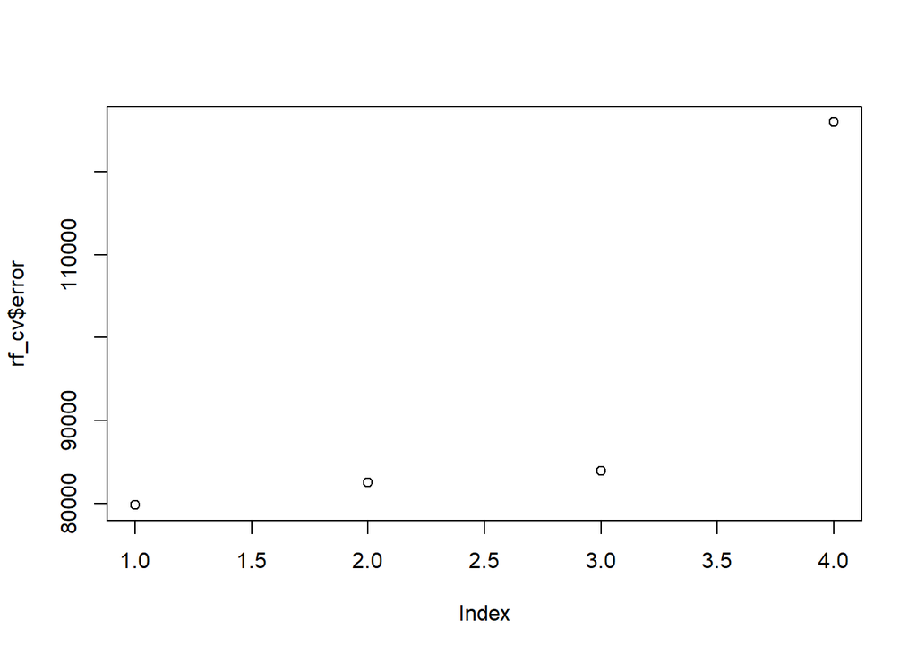

```r
plot(rf_cv$error)
```

```r
#predicting using RF_CV model
pred_rf_cv<-rf_cv$predicted[1]

#Calculating R2 for RF CV model
SSE_rf_cv1<-sum((pred_rf_cv-crime_data[16])^2)
SST<-sum((crime_data$Crime-mean(crime_data$Crime))^2)
R2_rf_cv<-1-SSE_rf_cv1/SST
```

## Conclusion

Clearly it can be seen using the random forest model deals with overfitting much better than decision tree. This can be seen by the errors from the cross validation model which are close to the random forest model. So, it can be seen that random forest are good in handling overfittiing.

## Question 10.2

Describe a situation or problem from your job, everyday life, current events, etc., for which a logistic regression model would be appropriate. List some (up to 5) predictors that you might use.

## Answer 10.2

We are looking to buy a new home. In this process we have created an excel which contains different criteria for putting a particular house in our dream list. The excel contains different predictors and the response is either 1(will consider the house) and 0(doesn’t fit our criteria). The predictors used are

1. Price
2. Distance from the train station
3. Distance to nearest school
4. Insurance cost
5. Down payment

So, any new prospective house can go through the model and its out put will be either 1 or 0.

## Question 10.3

1. Using the GermanCredit data set germancredit.txt from http://archive.ics.uci.edu/ml/machine-learning-databases/statlog/german / (description at http://archive.ics.uci.edu/ml/datasets/Statlog+%28German+Credit+ Data%29 ), use logistic regression to find a good predictive model for whether credit applicants are good credit risks or not. Show your model (factors used and their coefficients), the software output, and the quality of fit. You can use the glm function in R. To get a logistic regression (logit) model on data where the response is either zero or one, use family=binomial(link=”logit”) in your glm function call.
2. Because the model gives a result between 0 and 1, it requires setting a threshold probability to separate between “good” and “bad” answers. In this data set, they estimate that incorrectly identifying a bad customer as good, is 5 times worse than incorrectly classifying a good customer as bad. Determine a good threshold probability based on your model.